# 第11回 データの加工

プログラミング演習Ⅰ

佐藤 秀保

sato0035@toyo.jp

## 先週までの内容 (1)

- パッケージのインストール方法
  - `install.packages("パッケージ名")`
  - 一度，インストールすれば次回から実行不要
- パッケージの読込
  - `library(パッケージ名等)`
  - 原則，毎度実行が必要

## 先週までの内容 (2)

- **エクセルデータのアップロード**
  - Filesペイン→Upload
- **エクセルデータの読込**

```r
#パッケージのインストールは一度実行済みの場合は不要
install.packages("readxl")
library(readxl)
df <- read_excel("syokudo_data1.xlsx")
```

- `tidyverse`のパッケージのインストール

```r
#パッケージのインストールは一度実行済みの場合は不要
install.packages("tidyverse")
library(tidyverse)
```

## 準備

授業中のコードはすべてスクリプトに書き実行すること

## データ読込とパッケージ準備

- ACEにアップロードしたエクセルファイル「syokudo_data2」を`df`という名前で各自読み込むこと
  - 朝霞キャンパス食堂の日別売上データ（2026年6月1～24日）
    - （24日は14:30時点のデータ）
- `library(tidyverse)`を実行しておくこと

## `select`関数

- 列の抽出

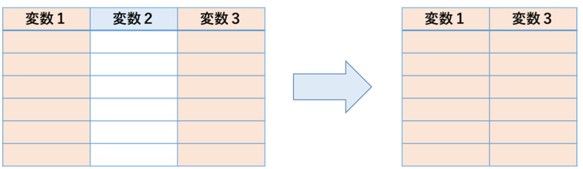

文法：`select(データフレーム名, 列名１, 列名2, ...)`

- `df`から「日付」，「総売上」の列を抽出
- `df1`という名前に保存

```r
df1 <- select(df, 日付, 総売上)
```

## `filter`関数

- 行の抽出

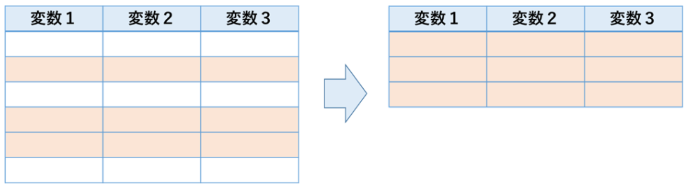

文法：`filter(データフレーム名, 条件式１, 条件式2, ...)`

- `df`から「総売上」> 0に該当する行を抽出
- `df2`という名前に保存

```r
df2 <- filter(df, 総売上 > 0)
```

## `mutate`関数

- 列の追加

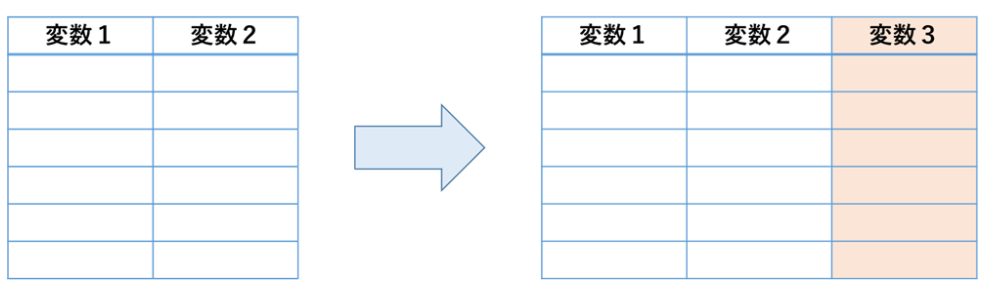

文法：`mutate(データフレーム名, 新しい列名1 = 計算式, 新しい列名2 = 計算式, ...)`

- `df`から「総売上」÷「客数」を行った結果を新しい列「客単価」として追加
- `df3`という名前に保存

```r
df3 <- mutate(df, 客単価 = 総売上 / 客数)
```

- `df`の「日付」から対応する曜日を検索し，新しい列「曜日」として追加
  - `weekdays(日付)`という関数・引数で計算可
- `df4`という名前に保存

```r
df4 <- mutate(df, 曜日 = weekdays(日付))
```

## `arrange`関数

- 行の並び替え

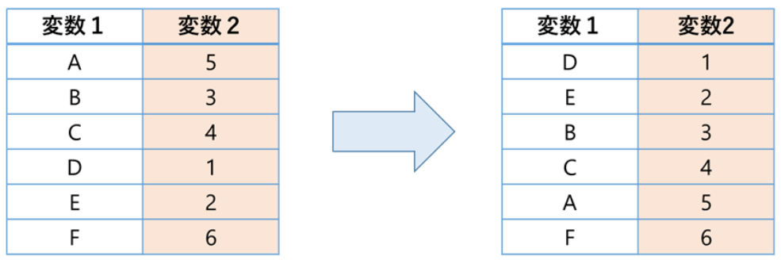

文法：`arrange(データフレーム名, 昇順に並び替えする変数)`

- `df`を「総売上」の昇順に並び替え
- `df5`という名前に保存

```r
df5 <- arrange(df, 総売上)
```

文法：`arrange(データフレーム名, desc(降順に並べ替えする変数))`

- `df`を「総売上」の降順**desc**endingに並び替え
- `df6`という名前に保存

```r
df6 <- arrange(df, desc(総売上))
```

## `rename`関数

- 列名の変更

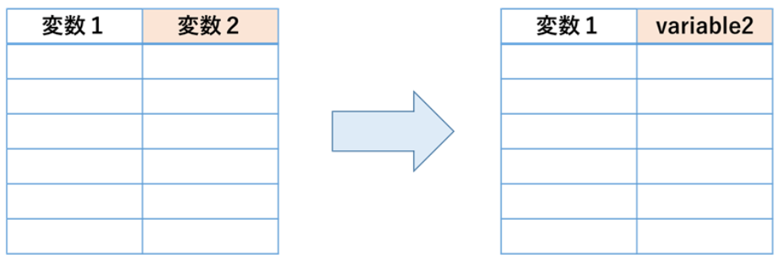

文法：`rename(データフレーム名, 新しい列名1 = 古い列名1, 新しい列名2 = 古い列名2, ...)`

- `df`の「日付」を「date」に変更
- `df7`という名前に保存

```r
df7 <- rename(df, date = 日付)
```

## `summarise`関数

- 記述統計量を計算しデータフレームに保存

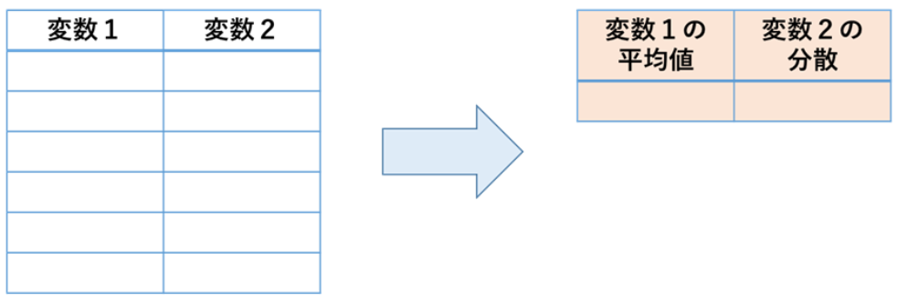

文法：`summarise(データフレーム名, 新しい列名1 = 記述統計計算の関数(計算する列名1), 新しい列名2 = 記述統計計算の関数(計算する列名2), ...)`

- `df`の「総売上」の平均値と「客数」の分散を計算
- `df8`という名前に保存
- ただし，NAの行は削除しないと計算ができないので先に`filter`をかけたデータフレームを作成しそれを用いる

```r
df_filter <- filter(df, 総売上 > 0, 客数 > 0)
df8 <- summarise(df_filter,
                 総売上の平均 = mean(総売上),
                 客数の分散 = var(客数))
```

## 演習

`df`のデータを用いて，「客数」の月曜日の平均値と「客数」の火曜日の平均値をそれぞれアトミックベクトルとして抽出し，その値を比較せよ．

- ヒント
  1. `filter`で「客数」の`NA`を削除
  2. `mutate`で「曜日」の列を追加
  3. `filter`で「Monday」を抽出
  4. `summarise`で平均を計算したデータフレームをゲット
  5. 4をアトミックベクトルとして抽出

※火曜日も上の方法と同様

ただし，3で月曜日を`filter`するときは，`filter(データフレーム名, 曜日 == "Monday")`のように==を使うことでその曜日に等しいという条件に合致する場合の行を判定し抽出できることに注意する．

## 課題

- ACEの小テスト：「第11回」
- ACEのレポート：「第11回」
  - ローカルに保存したlec11.Rを提出